# Assignment 2 Advanced Statistical Modeling

Jacolien van Rij Deadline: January 11, 2018

## Preparations

- Download the answer template (R Markdown) from Nestor and use that for creating your report. More information on R Markdown can be found here.
- Other directions for the R Markdown report:
  - Always include the code when you calculated or plotted information.
  - Do not include very long output - use `head` and similar functions to cut-off the output.
  - Use the html mark up `<ans>` for providing your answer to questions.
  - When the output, plots and/or code are not visible, please set the arguments `eval` and `include` of the R code chunks to TRUE as illustrated below:

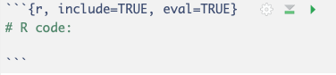

- Download the data and load it in R:

```r
# clean R working environment:
rm(list=ls())

# set working directory:
setwd("/Users/jacolien/Documents/Courses/AdvancedStatsModeling/Topic 2 LME/assignment/")

# Load data:
load("data_vanRij_2013.rda")

# Load packages:
library(plyr)
library(plotfunctions)
```

#### The data

The data for the assignment is from a dual-task self-paced reading time experiment of van Rij et al. (2013). In a self-paced reading time experiment, participants read sentences one word (group) at the time, and they press a button (i.e., space bar) to see the next word (group) to read. The idea is that increased processing difficulty results in longer reading times. The experiment of van Rij et al. was a dual-task experiment: to investigate the effect of working memory load on sentence processing, participants were presented with 3 or 6 digits (depending on the working memory load condition) that they had to remember while reading short stories using the self-paced reading paradigm. The trial sequence was as follows:

1. 3 or 6 digits were presented (depending on the working memory block)
2. Self-paced reading of a four-sentence story
3. Answering comprehension question about story
4. Recall memorized digits
5. Feedback on digit recall

The original research question was about whether working memory load changes the *subject preference* in adults when reading subject pronouns (‘he’, ‘she’) after a topic shift. Generally, when a subject pronoun is *ambiguous* [^1], listeners prefer the grammatical subject of the previous sentence as interpretation of the pronoun. We found that with increased working memory load, this subject bias decreased. Working memory load was manipulated by asking participants to remember 3 digits (low WM load condition) or 6 digits (high WM load condition) while reading short stories.

However, in the current assignment we would like to check two other questions:

- Part I: We would like to check whether participants show a preference for the left or right answer when they are faced with a higher working memory load.
- Part II: We would like to test whether working memory load and focus on the digit task affects the reading of the first word in the stories. The first word in the stories always introduced the first referent.

# PART I: Location preference

## Question 1: Descriptive statistics [5pt]

1. First, you are asked to check the structure of the data. Include the code in your report and the answer.
   - How many participants (column `id`) are included in the data?
   - How many trials *per subject* are included in the data?
   - How many different trials did the participants actually see in total? ( Hint: In the experiment two types of stories were presented, in random order. This data set only contains one of the story types, the other stories are excluded. )
2. Now visualize the grand averages of whether participants chose the answer on the right side of the screen (column `answer.position`) for the different relevant conditions:
   - Calculate 8 averages per participant (i.e., proportion of answers that were on the right side), for the combination of the predictors `wmTask`, `block`, and `prev.error`.
   - Calculate the general means for the 8 conditions based on the participants means calculated in Q1.a.
   - Calculate the SE (standard error of the mean) for the 8 conditions based on the participants means calculated in Q1.a. (Hint: you could use the function `se` from the package `plotfunctions` or you could calculate the SE yourself: $SE=\frac{SD}{\sqrt{N}}$).
3. Visualize the 8 condition averages with error bars ($\pm$ 1 SE). Two example plots with code (for different data) are provided to help you. But feel free to use other functions and code to visualize the data. Include the code and the plot. Make sure that the plot(s) meet the following criteria:
   - Clear axis labels and title(s);
   - Legend;
   - Clear distinction between the conditions by color or other layout options.

*Example 1: Barplot*

Here is an example of a barplot visualizing how often participants selected the firstly introduced referent for the two types of stories (‘-TS’ vs ‘+TS’), for the type of items (‘TEST’ vs ‘FILLER’), and for the two working memory conditions (‘low WM load’ vs ‘high WM load’). The data and code for calculating the means is not provided, only the code for plotting.

```r
# calculated means:
avg.mean
# calculated SEs:
avg.se
```

```
## , , -TS
##
##        high WM load low WM load
## FILLER   0.09871795  0.08846154
## TEST     0.71817766  0.75892857
##
## , , +TS
##
##        high WM load low WM load
## FILLER    0.8315629   0.8545482
## TEST      0.3230311   0.2146291
##
## , , -TS
##
##        high WM load low WM load
## FILLER   0.01953468  0.01633792
## TEST     0.02851566  0.02564361
##
## , , +TS
##
##        high WM load low WM load
## FILLER   0.02194568  0.01838515
## TEST     0.03119662  0.02554962
```

[figure not shown]

```r
# two panels and larger fonts:
par(mfrow=c(1,2))

# PLOT 1:
b <- barplot(avg.mean['TEST',,], beside = TRUE,
             col=c('steelblue1', 'steelblue4'), density=c(25,-1),
             main="Test items", ylab="Referent 1 answers", ylim=c(0,1))
errorBars(b, avg.mean['TEST',,], avg.se['TEST',,])
legend_margin('bottomleft', legend=c("low WM load", "high WM load"),
              fill=c('steelblue1', 'steelblue4'), density=c(25,-1),
              bty='n')

# PLOT 2:
b <- barplot(avg.mean['FILLER',,], beside = TRUE,
             col=c('steelblue1', 'steelblue4'), density=c(25,-1),
             main="Filler items", ylab="Referent 1 answers", ylim=c(0,1))
errorBars(b, avg.mean['FILLER',,], avg.se['FILLER',,])
legend_margin('bottomleft', legend=c("low WM load", "high WM load"),
              fill=c('steelblue1', 'steelblue4'), density=c(25,-1),
              bty='n')
```

*Example 2: Points*

Here we used a different way to calculate the means, so that the output is a data.frame. (Not for a particular reason, just as example.)

```r
# calculated means and SEs:
head(avg)
```

```
##   trial.TS   Type           WM  Ref1.mean    Ref1.se
## 1      -TS FILLER high WM load 0.09871795 0.01953468
## 2      -TS FILLER  low WM load 0.08846154 0.01633792
## 3      -TS   TEST high WM load 0.71817766 0.02851566
## 4      -TS   TEST  low WM load 0.75892857 0.02564361
## 5      +TS FILLER high WM load 0.83156288 0.02194568
## 6      +TS FILLER  low WM load 0.85454823 0.01838515
```

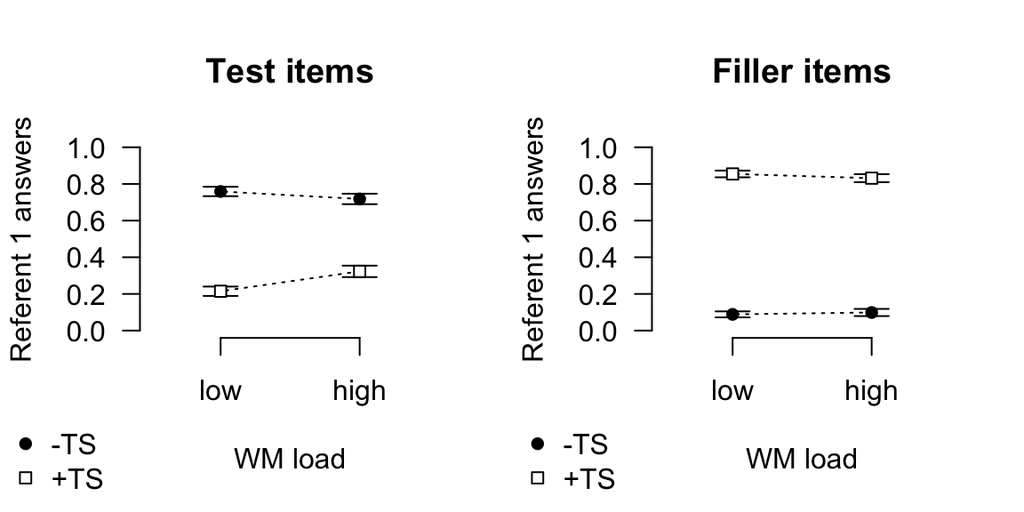

```r
# two panels and larger fonts:
par(mfrow=c(1,2))

avg$x <- ifelse(avg$WM == "low WM load", 1, 2)

# PLOT 1:
plot(c(), c(), xlim=c(.5,2.5), ylim=c(0,1),
     main="Test items", ylab="Referent 1 answers", xlab="WM load",
     axes=FALSE)
axis(1, at=c(1,2), labels=c("low", "high"))
axis(2, las=1)

with(avg[avg$Type=="TEST",], {
  errorBars(x, Ref1.mean, Ref1.se)
  lines(x[trial.TS=="+TS"], Ref1.mean[trial.TS=="+TS"], lty=3)
  lines(x[trial.TS=="-TS"], Ref1.mean[trial.TS=="-TS"], lty=3)
  points(x, Ref1.mean, pch=ifelse(trial.TS=="+TS", 22, 16), bg="white")
})
legend_margin('bottomleft', legend=c("-TS", "+TS"),
              pch=c(16, 22), pt.bg="white",
              bty='n')

# PLOT 2:
plot(c(), c(), xlim=c(.5,2.5), ylim=c(0,1),
     main="Filler items", ylab="Referent 1 answers", xlab="WM load",
     axes=FALSE)
axis(1, at=c(1,2), labels=c("low", "high"))
axis(2, las=1)

with(avg[avg$Type=="FILLER",], {
  errorBars(x, Ref1.mean, Ref1.se)
  lines(x[trial.TS=="+TS"], Ref1.mean[trial.TS=="+TS"], lty=3)
  lines(x[trial.TS=="-TS"], Ref1.mean[trial.TS=="-TS"], lty=3)
  points(x, Ref1.mean, pch=ifelse(trial.TS=="+TS", 22, 16), bg="white")
})
legend_margin('bottomleft', legend=c("-TS", "+TS"),
              pch=c(16, 22), pt.bg="white",
              bty='n')
```

## Question 2: Linear model [5pt]

1. Set up a linear regression model that models whether participants were more likely to choose the right or left answer (`answer.position`, the dependent variable) depending on the WM task (`wmTask`), block (`block`), and whether the preceeding trial was answered correctly or not (`prev.error`). Include all interactions. Hints:
   - The dependent variable `answer.position` has two values, and could be used as binomial predictor when it is converted to a factor (`dat$answer.position <- as.factor(dat$answer.position)`).
   - As the dependent variable is binomial, make sure to tell the glm that we are dealing with binomial data.
   - Check the number of values for `block`. Should this be a numerical predictor?

```r
m1 <- glm( answer.position ~ ... )
```

2. Use a backward-fitting model comparison procedure to determine the best-fitting model. Include the code and your conclusions (i.e., for each comparison state shortly which model you prefer and why). Hint: use `anova(..., test="Chisq")` for model comparisons.

## Question 3: Interpretation logistic regression [5pt]

1. Logit values
   - Summarize in words how logit values are related to proportions.
   - Which of the two levels of `answer.position` is associated with higher logit values and which of the levels with lower logit values? Which function could be used to find out the coding that is used for these two levels?
2. Inspect the summary of the best-fitting model.
   - What does the intercept represent?
   - Describe the model’s estimates for the different conditions based on the summary. If your best-fitting model contains one or more interactions, describe the estimated interaction(s) based on the summary estimates. If your best-fitting model only contains main effects, describe whether and how these predictors influence the participants’ answer preferences.
3. Fitted values
   - Below we retrieve the model’s estimates for each condition on the logit scale, with the associated standard errors. Run the code and inspect the output. In which condition(s) do participants behave significantly different from chance performance? Explain why you concluded that the estimates in these conditions are different from chance.

```r
newd <- expand.grid(wmTask = unique(dat$wmTask),
                    block=unique(dat$block),
                    prev.error=unique(dat$prev.error))

# fitted effects on logit scale:
fv <- predict.glm(m2, newd, type='link', se.fit=TRUE)
newd$fit <- fv$fit
newd$se <- fv$se.fit
# show estimates:
newd
```

# PART II: Reading times

In the second part of the assignment we would like to test whether working memory load and focus on the digit task affects the reading of the first word in the stories. The first word in the stories always introduced the first referent. The picture below visualizes the average reading times on the first sentence of the story for the two working memory conditions. We will only consider the reading time on the first word (Sentence position = 1).

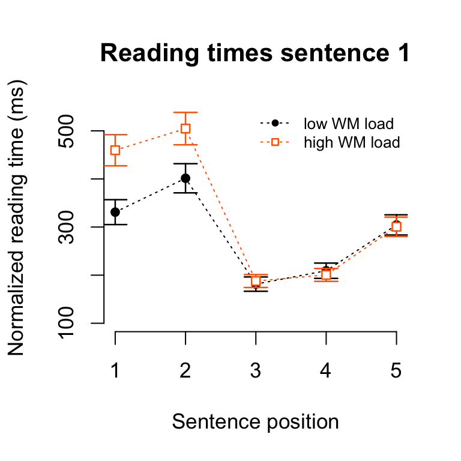

## Question 1: Data preparation [5pt]

The column `referent1.RT` contains the reading times in miliseconds for reading the first word of the first sentence of each trial.

```r
dat$cTrial <- ...
```

## Question 2: Analysis [5pt]

1. Random intercepts model
   - Setup a LME model `m1` to investigate the effects of the WM task (`wmTask`) and trial (`cTrial`) and include random intercepts for participants (`id`) and items (`trial.code`). Run the model and include the code in your report.
2. Include the summary output in your report.
   - Which of the two predictors shows more variation in reading times: participants or items? Explain how you can see this in the summary.
3. Random slopes model
   - Test with model comparisons which random slopes (for `wmTask` and `cTrial`) you need to include for participants and items. Include the code and output for the model comparisons in your report, and also a short note with each model comparison which model you prefer. Hint: include `REML=TRUE` in the models when comparing random effects, and use `anova(..., refit=FALSE)` for the model comparisons.
4. Fixed effects
   - With the random effects structure that you determined in the previous question, investigate whether the interaction between WM load (`wmTask`) and Trial (`cTrial`) is significant. Include the code, the output, and your conclusion in the report.

## Question 3: Reporting the results [5pt]

Write a short paragraph for a paper in which you report the reading time analysis. For this question only focus on the *fixed effects* (you can ignore the random effects for this assignment). Include the results of statistical tests. You can split up the paragraph in the following subsections:

1. Describe how you determined the best-fitting model.
2. Describe the model estimates for the effects of WM load and Trial (i.e., change in reading times over the course of the experiment) on the reading times.
[^1]: *Ambiguous* means in this context that there are multiple referents with the same gender as the pronoun mentioned in the linguistic context. In the example sentence “John gave Bill the book. He had read more books from the same author.”, the pronoun ‘he’ is ambiguous because it could refer to John or to Bill.